```r
> library(knitr)
> library(extrafont)
> library(stringr)
> library(ggplot2)
> library(dplyr)
>
> # remove scientific notation unless the numbers get really big
> options(scipen = 5)
>
> experiment = c(rep("P10_control", 6), rep("P10_rescue", 6), rep("P13_control",
+     6), rep("P13_rescue", 6))
> experiment = rep(experiment, 16)
> age = unname(sapply(experiment, function(x) {
+     strsplit(x, "_")[[1]][1]
+ }))
> status = unname(sapply(experiment, function(x) {
+     strsplit(x, "_")[[1]][2]
+ }))
> metadata = data.frame(experiment = experiment, age = age, status = status)
>
> umi_count_file = "../data/retinaAligned.out.cleaned.counts_umi.gz"
>
>
> umi_counts = function(umi_count_file) {
+     plate = tbl_df(read.table(gzfile(umi_count_file), sep = "\t"))
+     colnames(plate) = c("umi", "gene", "cell", "counts")
+     byumi = plate %>% group_by(umi) %>% summarise(sum = sum(counts))
+     byumi = subset(byumi, !grepl("N", umi))
+     byumi$umi = as.character(byumi$umi)
+     return(byumi)
+ }
```

# Exploratory analysis

There is not a huge skew in UMI distribution towards G-repeats that we have seen with some other libraries, the top UMI tags look pretty reasonable:

```r
> umi = umi_counts(umi_count_file)
> umi = umi[order(-umi$sum), ]
> kable(head(umi, 25), format = "html")
```

| umi | sum |
| --- | --- |
| ACAAGTGAAA | 14760 |
| GGGGTAGAAT | 14117 |
| GCGTGTGCTA | 13299 |
| GGATGATTGT | 12616 |
| GGGACGATTT | 12597 |
| CGCCAACAGT | 12408 |
| CGTTACTTGC | 11713 |
| GGCAGGTCAA | 11631 |
| CGGGGAGCGT | 11578 |
| AAATAGAAAC | 11346 |
| GCGGAGAAGA | 11338 |
| AGCCCGTCGT | 10981 |
| GATGAGGGGT | 10958 |
| TGGGGGGTGG | 10793 |
| GCTCTCATGG | 10762 |
| AACGGTAGGG | 10698 |
| AAACTGTACA | 10689 |
| TGGAGCTGAG | 10671 |
| GGGGGCTTTA | 10610 |
| TATGAAAGGC | 10575 |
| GTGCACAGGG | 10505 |
| ACAGGAGGCG | 10354 |
| TTCTGTAGAG | 10161 |
| GCTGTTGTCG | 10135 |
| GGACGACGGA | 10134 |

The UMI content is slightly skewed, with UMI with a higher GC content more likely to be sequenced:

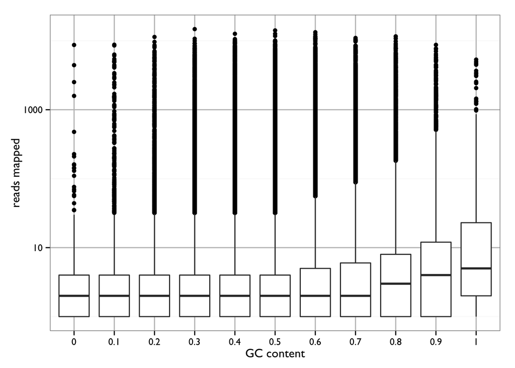

```r
> umi$G = str_count(umi$umi, "G")
> umi$T = str_count(umi$umi, "T")
> umi$C = str_count(umi$umi, "C")
> umi$A = str_count(umi$umi, "A")
> umi$GC = (umi$G + umi$C)/(umi$G + umi$C + umi$T + umi$A)
> ggplot(umi, aes(as.factor(GC), sum)) + geom_boxplot() + scale_y_log10() + xlab("GC content") +
+     ylab("reads mapped") + theme_bw(base_size = 12, base_family = "Gill Sans MT") +
+     theme(panel.grid.major = element_line(size = 0.5, color = "grey"))
```

```r
> sort_samplenames = function(samplenames) {
+     sample = unlist(lapply(str_split(samplenames, "[.]"), function(x) {
+         x[1]
+     }))
+     ends = unlist(lapply(str_split(samplenames, "[.]"), function(x) {
+         x[2]
+     }))
+     plate = unlist(lapply(str_split(samplenames, "_"), function(x) {
+         x[1]
+     }))
+     well = unlist(lapply(str_split(samplenames, "_"), function(x) {
+         x[2]
+     }))
+     row = substr(well, 1, 1)
+     plate = as.numeric(substr(well, 2, 3))
+     df = data.frame(id = samplenames, row = row, plate = plate)
+     ord = df[order(df$row, df$plate), ]
+     return(as.character(ord$id))
+ }
>
> counts_from_umi = function(umi_count_file, tag) {
+     plate = tbl_df(read.table(gzfile(umi_count_file), sep = "\t"))
+     colnames(plate) = c("umi", "gene", "cell", "counts")
+     byumi = plate %>% group_by(umi) %>% summarise(sum = sum(counts))
+     umi_to_keep = subset(byumi, !grepl("N", umi))$umi
+     umi_filter = subset(plate, plate$umi %in% umi_to_keep)
+     umi_filter$counts_umi = 1
+     bygene_sample = umi_filter %>% group_by(gene, cell) %>% summarise(sum = sum(counts_umi))
+     bygene_sample = data.frame(bygene_sample)
+     counts = reshape(bygene_sample, timevar = "cell", idvar = "gene", direction = "wide")
+     counts[is.na(counts)] = 0
+     row.names(counts) = counts$gene
+     counts$gene = NULL
+     colnames(counts) = lapply(colnames(counts), function(x) {
+         paste(tag, strsplit(x, "sum.")[[1]][2], sep = ".")
+     })
+     counts = counts[order(rownames(counts)), sort_samplenames(colnames(counts))]
+     return(counts)
+ }
>
> umi = counts_from_umi(umi_count_file, "retina")
> colnames(umi) = unname(sapply(colnames(umi), function(x) {
+     strsplit(x, "_")[[1]][2]
+ }))
> metadata$well = colnames(umi)
> metadata$row = substr(colnames(umi), 1, 1)
```

There are only a small number of genes detected in each well.

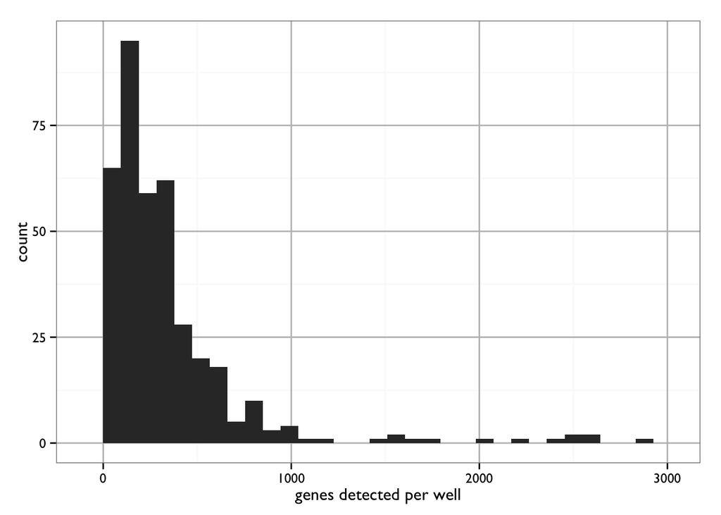

```r
> qplot(colSums(umi > 0)) + geom_histogram() + xlab("genes detected per well") +
+     theme_bw(base_size = 12, base_family = "Gill Sans MT") + theme(panel.grid.major = element_line(size = 0.5,
+     color = "grey"))
```

There are only a small number of counts per well, less than 1000:

```r
> summary(colSums(umi))
```

```
   Min. 1st Qu.  Median    Mean 3rd Qu.    Max.
   12.0   172.5   404.5   705.1   747.0 11630.0
```

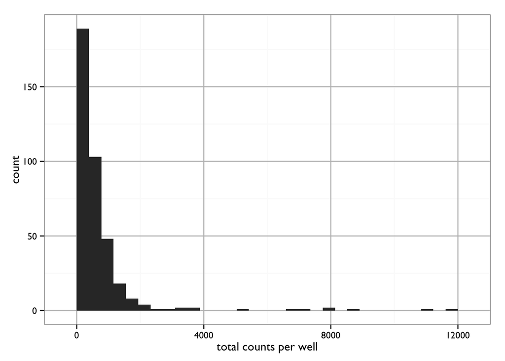

```r
> qplot(colSums(umi)) + geom_histogram() + xlab("total counts per well") + theme_bw(base_size = 12,
+     base_family = "Gill Sans MT") + theme(panel.grid.major = element_line(size = 0.5,
+     color = "grey"))
```

Most detected genes only have a small number of reads associated with them with a large number of genes just having one read of evidence.

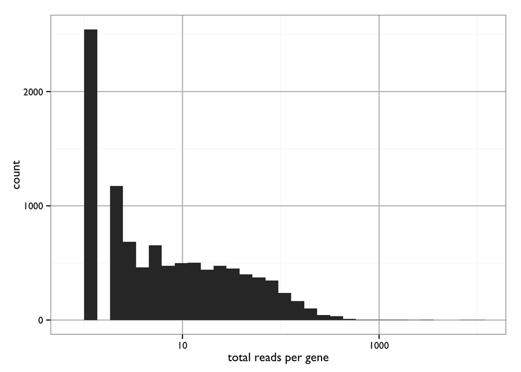

```r
> qplot(rowSums(umi)) + geom_histogram() + xlab("total reads per gene") + theme_bw(base_size = 12,
+     base_family = "Gill Sans MT") + scale_x_log10() + theme(panel.grid.major = element_line(size = 0.5,
+     color = "grey"))
```

The P10 and P13 cells have different distributions of counts which will confound things somewhat:

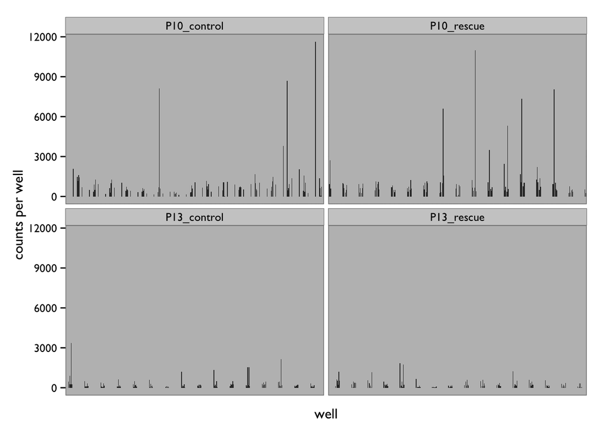

```r
> df = data.frame(well = colnames(umi), counts = colSums(umi))
> m = merge(df, metadata, by = "well", all.x = TRUE)
> ggplot(m, aes(well, counts)) + geom_bar(stat = "identity") + facet_wrap(~experiment) +
+     ylab("counts per well") + theme_bw(base_size = 12, base_family = "Gill Sans MT") +
+     theme(panel.grid.major = element_line(size = 0.5, color = "grey"), axis.ticks.x = element_blank(),
+         axis.text.x = element_blank())
```

There isn’t really any clustering of the samples based on age or rescue status, which is not good if we are hoping to call anything DE.

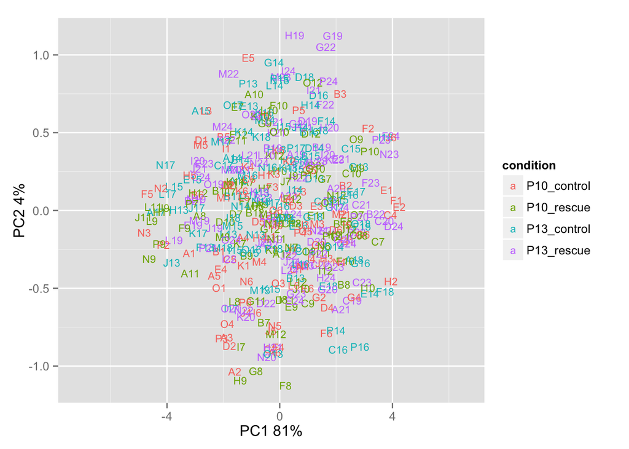

```r
> library(CHBUtils)
> mds(cor(umi), condition = experiment)
```

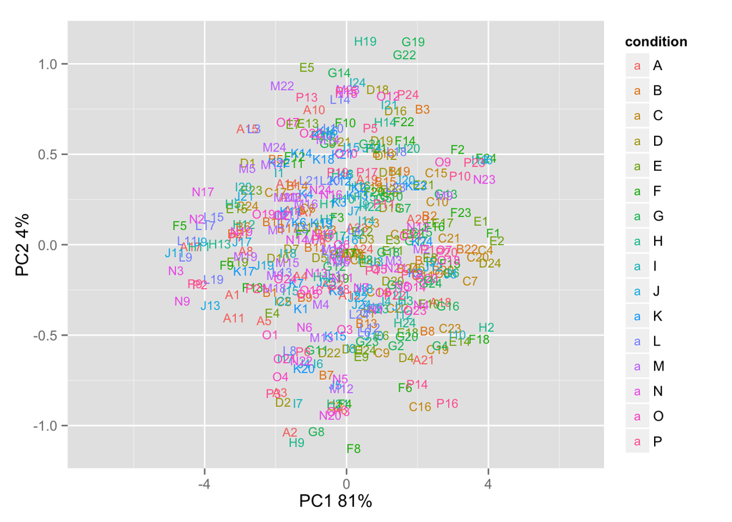

```r
> mds(cor(umi), condition = metadata$row)
```

Hierarchical clustering shows this as well, the colors at the top are the different experiments. This data has each gene normalized by the maximum count for that gene.

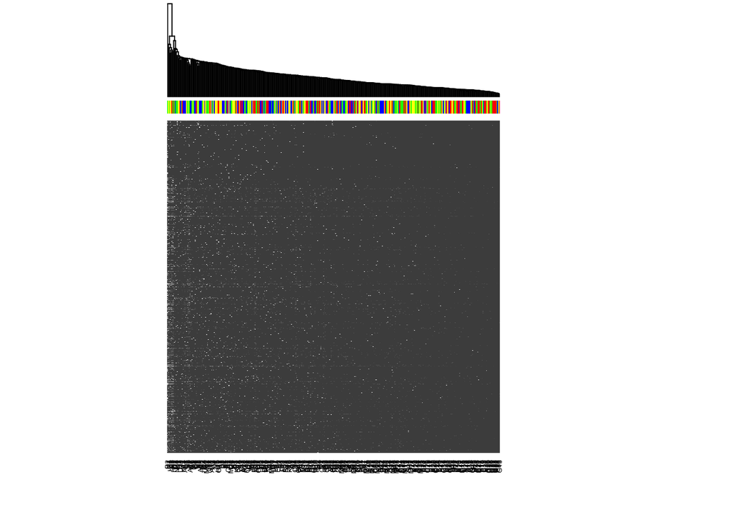

```r
> exp_colors = data.frame(experiment = c("P10_control", "P10_rescue", "P13_control",
+     "P13_rescue"), colors = c("blue", "red", "yellow", "green"))
> colors = merge(metadata, exp_colors, by = "experiment", all.x = TRUE)
>
> m = as.matrix(umi)
> heatmap(m/apply(m, 1, max), zlim = c(0, 1), col = gray.colors(100), Rowv = NA,
+     labRow = NA, scale = "none", ColSideColors = as.character(colors$colors))
```

# Differential expression

Based on the above we shouldn’t really be expecting there to be any differences. I tried running SCDE for all the samples, P10 vs P13 and rescue vs control and neither came out as anything. I also treated P10 and P13 as a batch effect and looked at the effect of rescue vs control and couldn’t find anything either.

```r
> library(scde)
>
> scde_count_prep = function(counts, groups, batch = NULL, sample_min = 5000,
+     sample_max = Inf) {
+     keep_genes = rowSums(counts) > 0
+     keep_samples = (colSums(counts) > sample_min) & (colSums(counts) < sample_max)
+     groups = droplevels(groups[keep_samples])
+     counts = counts[keep_genes, keep_samples]
+     names(groups) = colnames(counts)
+     if (!any(unlist(lapply(batch, is.na)))) {
+         batch = droplevels(batch[keep_samples])
+         names(batch) = colnames(counts)
+     }
+     return(list(counts = counts, groups = groups, batch = batch))
+ }
>
>
> scde_de = function(scde) {
+     o.ifm = scde.error.models(counts = scde$counts, groups = scde$groups, n.cores = 1,
+         threshold.segmentation = TRUE, save.crossfit.plots = FALSE, save.model.plots = FALSE,
+         verbose = 2)
+     valid.cells = o.ifm$corr.a > 0
+     o.ifm = o.ifm[valid.cells, ]
+     groups = scde$groups[valid.cells]
+     names(groups) = row.names(o.ifm)
+     if (!any(unlist(lapply(scde$batch, is.na)))) {
+         batch = scde$batch[valid.cells]
+         names(batch) = row.names(o.ifm)
+     }
+     counts = scde$counts[, valid.cells]
+     o.prior = scde.expression.prior(models = o.ifm, counts = scde$counts, length.out = 400,
+         show.plot = T)
+     ediff = scde.expression.difference(o.ifm, scde$counts, o.prior, groups = groups,
+         batch = batch, n.randomizations = 100, verbose = 1)
+     if (!any(unlist(lapply(scde$batch, is.na)))) {
+         ediff = ediff$batch.adjusted
+     }
+
+     ediff$pvalue = pnorm(-(abs(ediff$Z))) * 2
+     ediff$padj = p.adjust(ediff$pvalue)
+     return(ediff)
+ }
```

```r
> s = scde_count_prep(umi, metadata$status, metadata$age, 1000, 20000)
> d = scde_de(s)
```

```
cross-fitting cells.
building individual error models.
```

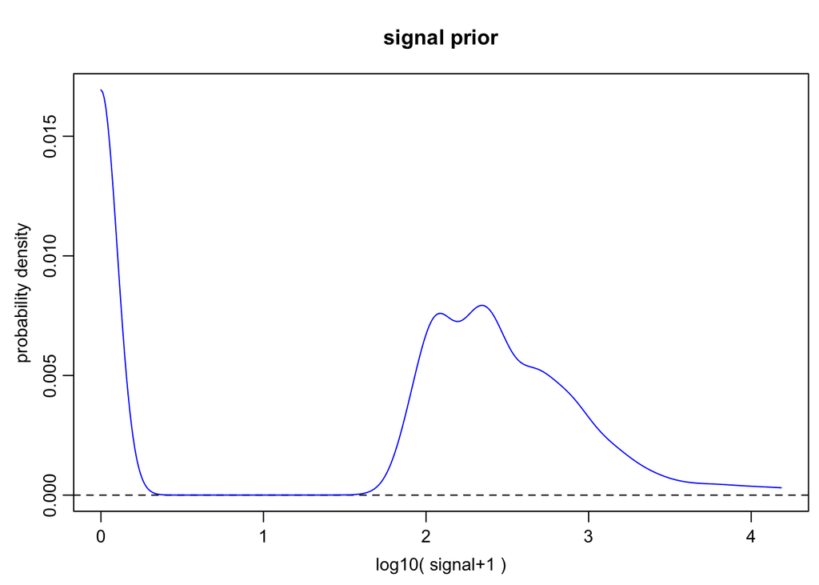

```
controlling for batch effects. interaction:
         batch
groups    P10 P13
  control  28   6
  rescue   28   5
calculating batch posteriors
calculating batch differences
calculating difference posterior
summarizing differences
adjusting for batch effects
```

```r
> table(d$padj < 0.05)
```

```
FALSE
10082
```